# Analysing biomass and yield of two contrasting leaf architectures of wheat

Ram Ghimire

CSIRO Agriculture & Food // Team - Maximising Yield Potential

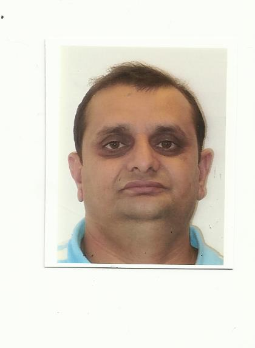

# Introduction

My name is Ram Ghimire, currently working as a Research Projects Officer in wheat leaf architecture and yield project. I have been working with data in crop physiology & agronomy for many years but have had no experience in R. Most of my data manipulation and visualisation are done in excel. I came to know about Data School from colleagues and got opportunity to join this year. Before joining Data School, I was used to spending a lot of time working with data mostly in excel spreadsheets. Now, I am delighted to see how amazing R can be for processing and visualisation of the field and laboratory data that I collect every year.

# My Project

Canopy architecture in wheat affects light penetration & subsequent leaf photosynthesis which in turn influences solar radiation use efficiency during stem elongation and anthesis, ultimately affecting above ground biomass & crop yield. The aim of this study is to investigate if two contrasting leaf architecture influence key economic traits of wheat lines. In this experiment important traits are evaluated for canopy architecture in a study population (n=315 lines) in two replications. Those lines, including erect and floppy canopy of varying degrees, were grown in 2019 wheat season in Ginninderra Experiment Station, ACT. The traits evaluated were upper leaf canopy score during anthesis, anthesis biomass, days to anthesis, plant height, peduncle length and grain yield. Data collected of those triats were then cleaned & analysed in R using tidyverse packages.

## Preliminary results

In this study we evaluated canopy architecture lines developed from Australian wheats. Line selection based on canopy architecture looks promising at the plot scale providing weather conditions are favourable leading up to flowering time so that the genetic potential of the upper leaves in the canopy is properly expressed. As is evident in Figures 1 & 3 imporant economic traits: yield, anthesis biomass & number of days to flowering respond positively to lower canopy score (erect canopy architecture), which corroborates previous findings by R.A Richards et al. 2019. However,because of drier than average growing season of 2019 in ACT leading up to flowering, the architecture score was skewed to more erect types such as lower score values in 1 to 10 scale (Table 1). Plant height and peduncle length demonstrate linear relationship as shown in Figure 2. This study is expected to help selection in easily observed traits that could be important in breeding so as to increase canopy light interception and radiation use efficiency during the critical period of yield formation.

Table 1: Key traits measured in spring wheat lines

| line | rep | canopy score | days to flowering | plant height (cm) | anthesis biomass (g) | peduncle length (cm) | yield (g/m^2) |
| --- | --- | --- | --- | --- | --- | --- | --- |
| 26 | 1 | 2.0 | 168 | 87 | 608.54 | 22 | 551.51 |
| 43 | 1 | 1.7 | 171 | 75 | 611.65 | 11 | 650.90 |
| 75 | 1 | 3.7 | 176 | 70 | 564.67 | 14 | 517.92 |
| 92 | 1 | 2.0 | 170 | 85 | 560.50 | 20 | 599.10 |
| 118 | 1 | 2.7 | 178 | 84 | 657.26 | 6 | 705.49 |

**Contrasting wheat leaf architectures**

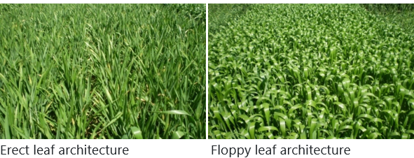

**Plots from R**

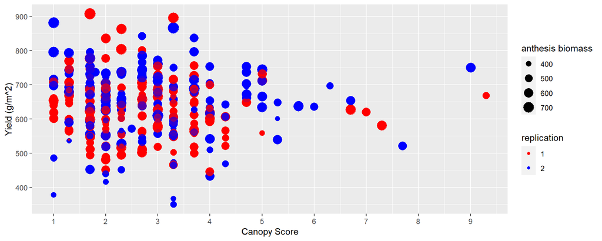

Figure 1: Grain yield & anthesis biomass in erect & floppy wheat lines

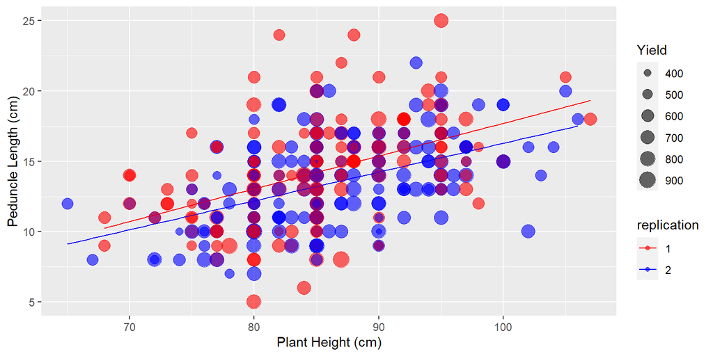

Figure 2: Plant height, peduncle length & yield in erect & floppy wheat lines

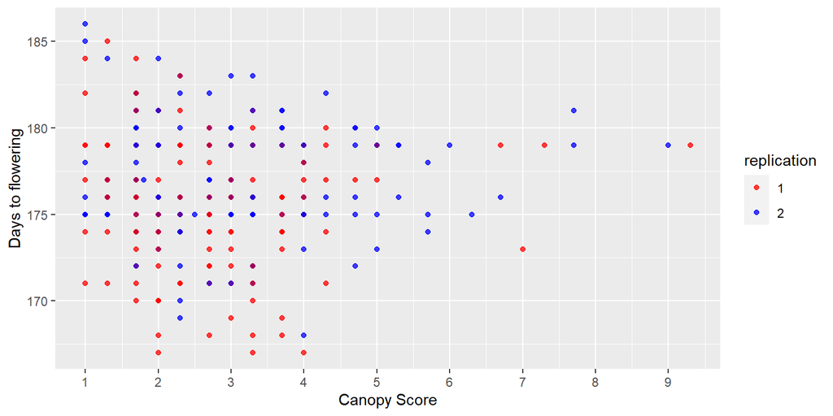

Figure 3: Days to flowering trait distribution in erect & floppy wheat lines

# My Digital Toolbox

For this project, I have been using the R version 3.6.3 and the digital tools such as tidyverse, ggplot2, kableExtra and imager.

# My time went …

Understanding of Git and Github & tidying up data were at first challenging lessons to me. I spent substantial amount of my time in catching up with those training lessons, reading, and writing R code to catch up those lessons. I enjoyed practicing ggplot and gganimate lessons, a great way to visualise and quickly grasp features of data. I also learnt to write codes in R to bring data together in one clean data format which can reproduce a report at need in future.

# Next steps

I will continue using R in my work so as to keep improving my R skills. I look forward to using R along with my project & team colleagues. This skill set will certainly motivate me to actively participate in developing of trial design, data manipulation, visualisation, analysis, reporting and publishing in my designated project & team.

# My Data School Experience

I was met with both challenging & exciting times in data school. One of my greatest challenges was to soar up own courage to learn and adopt a new learning platform, mostly in WebEx and Teams platforms, to wrangle data. I also spent extra time to learn from online video lessons. I really enjoyed all data school lessons but my favourite ones are ggplot and gganimate, of which, I have also used ggplot in this project. I was also frequently sharing interesting visualisations of project data with my team colleagues and was greatly encouraged by feedback, a moment of instant satisfaction.

# My thanks to you

Stephen Pearce, Kerensa McElroy, Luke Barret, Aswin Singaram Natarajan, Emmett Leyne, Gilbert Permaloo and other helpers who have dedicated their time to teach us R in classroom and also in group sessions. Special thanks go to Kristian Goodacre for amazingly organising the whole training program & ensuring that everyone is on board during this time different from a normal settings. Also great thanks to my research group: Richard Richards, Anne Rae, Wolfgang Spielmeyer and Gonzalo Estavillo for allowing me opportunity to learn R through Data School FOCUS.